# TubeSpam

Alison Harper

2025-03-05

The data comes from a freely available source here: http://www.dt.fee.unicamp.br/~tiago//youtubespamcollection/

Alberto, T. C., Lochter, J. V., & Almeida, T. A. 2015. TubeSpam: Comment Spam Filtering on YouTube. 2015 IEEE 14th International Conference on Machine Learning and Applications (ICMLA), 138–143. ieeexplore.ieee.org.

We want to build a model that looks at the linguistic properties of the data, and uses it for making predictions. class: 1= spam 0=ham

```r
rm(list = ls())
gc()
```

```
##           used (Mb) gc trigger (Mb) max used (Mb)
## Ncells  608608 32.6    1392490 74.4   692780 37.0
## Vcells 1150298  8.8    8388608 64.0  1929374 14.8
```

```r
library(devtools)
library(tidyverse)
library(tidytext)
library(quanteda)
if (!require("quanteda.dictionaries", character.only = TRUE)) {
  if (!requireNamespace("remotes", quietly = TRUE)) install.packages("remotes")
  remotes::install_github("kbenoit/quanteda.dictionaries")
}
library(quanteda.dictionaries)
```

# Import the data

Create tokens.

Regular expressions cheatsheets: https://hypebright.nl/index.php/en/2020/05/25/ultimate-cheatsheet-for-regex-in-r-2/ and https://gist.github.com/shakahl/43443dcba2c8105218350bf14df2c610 are both nice.

The command \w matches word characters, things that are used in writing typical English words. `unnest_tokens` will create tokens (unigrams). New column is called ‘word’, and will contain content from ‘content’

Text cleaning step!

```r
data("stop_words")

yt %>%  unnest_tokens(word, content) %>% #give new column a name - we called it 'word'
  count(word, sort=TRUE)
```

```
## # A tibble: 4,138 × 2
##    word      n
##    <chr> <int>
##  1 i       636
##  2 this    606
##  3 the     570
##  4 to      498
##  5 a       458
##  6 and     451
##  7 my      412
##  8 you     406
##  9 out     367
## 10 check   364
## # ℹ 4,128 more rows
```

```r
yt_tokens <- yt %>%
  unnest_tokens(word, content) %>%      # create the tokens
  mutate(word = tolower(word)) %>%      # make sure everything is lowercase
  anti_join(stop_words) %>%             # remove the stop words
  filter(nchar(word) >= 2) %>%          # remove anything that's short
  filter(grepl("\\w+", word))           # delete any punctuation or symbols (words only)
x <- paste(sort(unique(yt_tokens$word)), collapse = ' ')  # unique tokens only sorted - just to have a look
```

Most common words?

```r
yt_tokens %>%
  count(word) %>%
  arrange(-n)
```

```
## # A tibble: 3,687 × 2
##    word          n
##    <chr>     <int>
##  1 check       364
##  2 br          250
##  3 video       238
##  4 song        233
##  5 youtube     198
##  6 love        172
##  7 subscribe   161
##  8 39          156
##  9 http        143
## 10 amp         129
## # ℹ 3,677 more rows
```

```r
yt_tokens %>%  filter(word == "39")
```

```
## # A tibble: 156 × 6
##    class file                             id    author comment_date        word
##    <dbl> <chr>                            <chr> <chr>  <dttm>              <chr>
##  1     0 Youtube 01-comments Psy.csv      z135… Spenc… 2014-11-08 05:29:26 39
##  2     0 Youtube 04-comments KatyPerry.c… z13m… micha… 2014-10-30 05:20:18 39
##  3     1 Youtube 07-comments LMFAO.csv    z13t… LaS M… 2015-05-28 19:23:35 39
##  4     1 Youtube 07-comments LMFAO.csv    z13t… LaS M… 2015-05-28 19:23:35 39
##  5     0 Youtube 07-comments LMFAO.csv    z13y… LoL G… 2015-05-27 13:37:19 39
##  6     0 Youtube 07-comments LMFAO.csv    z12s… breat… 2015-05-26 22:21:28 39
##  7     0 Youtube 07-comments LMFAO.csv    z12l… goofy… 2015-05-26 20:03:52 39
##  8     0 Youtube 07-comments LMFAO.csv    z12s… Like👑… 2015-05-26 16:56:19 39
##  9     0 Youtube 07-comments LMFAO.csv    z120… Shock… 2015-05-26 02:03:46 39
## 10     0 Youtube 07-comments LMFAO.csv    z120… Shock… 2015-05-26 02:03:46 39
## # ℹ 146 more rows
```

```r
yt %>% filter(id == "z12sulyo4qmyjvjvm23tznvzfnboetfuj") %>% pull(content)
```

```
## [1] "I fuckin love this song!<br /><br /><br />After, I&#39;m sexy and I know it "
```

Some words are used frequently in every comment, we want to know terms that are used in specific comments.

Compute the TF-IDF for the terms.

```r
word_tfidf <- yt_tokens %>%
  count(id, word, sort = T) %>%
  bind_tf_idf(word, id, n)

word_tfidf %>%
  arrange(-tf_idf)
```

```
## # A tibble: 10,461 × 6
##    id                                          word         n    tf   idf tf_idf
##    <chr>                                       <chr>    <int> <dbl> <dbl>  <dbl>
##  1 _2viQ_Qnc68fX3dYsfYuM-m4ELMJvxOQBmBOFHqGOk0 beutiful     1     1  7.43   7.43
##  2 z125v3ozoqenvthaz04cdtajsmzwgxkwxug0k       superr       1     1  7.43   7.43
##  3 z12agrbxiwabvrb2g22pfpcqys2eyrwbd04         nicei        1     1  7.43   7.43
##  4 z12ai5agdlawczj5x04cfhbr2vuezzvox1s         collabo…     1     1  7.43   7.43
##  5 z12bjffg3yu4ybx4e04cjzfbyxqcdzyxl3s         hardcore     1     1  7.43   7.43
##  6 z12gcfvpsr3au3vg104cdpw5rvbivre5aeg         eminen       1     1  7.43   7.43
##  7 z12jf1h5lznmuhcuw22ruxdyxp2eh32ch           likkee       1     1  7.43   7.43
##  8 z12jjrfyukjlw5wyl04cddbo5pysslphbqs0k       epic         1     1  7.43   7.43
##  9 z12kstz4owbggv12p230vpcwntjbyrqim04         fit          1     1  7.43   7.43
## 10 z12lcb0rxw3qtlsqm04cebpbjkqjtdza1xs0k       telepho…     1     1  7.43   7.43
## # ℹ 10,451 more rows
```

Number of unique words.

```r
n_distinct(yt_tokens$word)
```

```
## [1] 3687
```

```r
count(yt_tokens, word, sort = T) %>% head(10) # common words
```

```
## # A tibble: 10 × 2
##    word          n
##    <chr>     <int>
##  1 check       364
##  2 br          250
##  3 video       238
##  4 song        233
##  5 youtube     198
##  6 love        172
##  7 subscribe   161
##  8 39          156
##  9 http        143
## 10 amp         129
```

```r
count(yt_tokens, word, sort = T) %>% tail(10) # least common words
```

```
## # A tibble: 10 × 2
##    word                              n
##    <chr>                         <int>
##  1 ｃｏｍｍｅｎｔ                    1
##  2 ｄａｍｎ                          1
##  3 ｅｂａｙ                          1
##  4 ｆａｎｃy                         1
##  5 ｈｔｔｐ                          1
##  6 ｉｓ                              1
##  7 ｓｈｏｅｃｏｌｌｅｃｔｏｒ314     1
##  8 ｔｈｉｓ                          1
##  9 ｕｓｒ                            1
## 10 ｗｗｗ                            1
```

Create test and training sets the same way that they did in the paper. They did it by using the first 70% of each set of comments as the training, and tested on the last 30% of the comments. We can’t do it across all comments since - well, look:

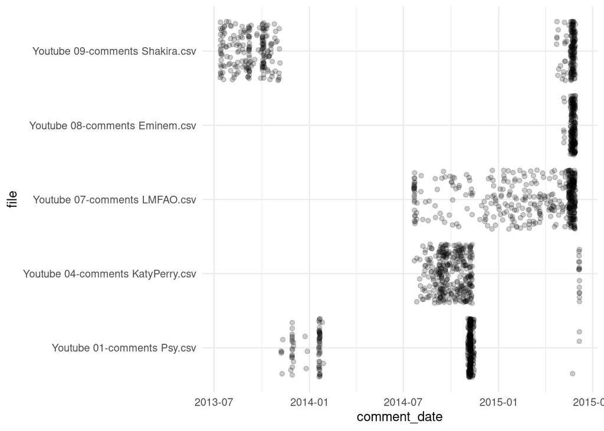

```r
ggplot(yt, aes(x = comment_date, y = file)) +
  geom_jitter(alpha = 0.2) +      # try comparing with geom_point and/or removing alpha
  theme_minimal()                 # try removing this line (and the +)
```

The comment dates are very different depending on the video. Look at training and test sets - test set is most recent comments

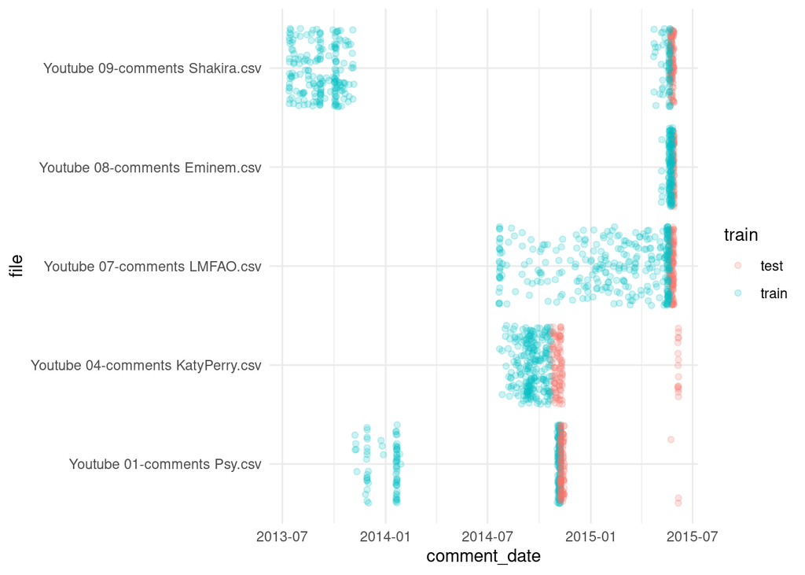

```r
yt <- yt %>%
  group_by(file) %>%
  mutate(date_decile = ntile(comment_date, 10)) %>%              # break up and divide into 10 even parts based on date
  mutate(train = ifelse(date_decile <= 7, 'train', 'test')) %>%  # train-test split on each file
  ungroup()
ggplot(yt, aes(x = comment_date, y = file, color = train)) +     # visualise the split!
  geom_jitter(alpha = 0.2) +
  theme_minimal()
```

Need to cast it into a matrix for these next several methods. This is a document term matrix - we talked about them in the lecture - a frequency table of words for each observation.

Its very long - we will make it very wide

https://www.tidytextmining.com/dtm.html

```r
yt_m <- word_tfidf %>%
  cast_dtm(id, word, tf_idf) %>%      # rows, columns, information inside it
  as.matrix
```

The DTM massive! Don’t try to look at it yet. Lets’ look at the top left corner of this tf-idf term document matrix looks like. (You could calculate a distance matrix from this, and then do some clustering or pca on it…but we won’t)

```r
yt_m[1:5, 1:5]
```

```
##                                              Terms
## Docs                                                 amp    48051       http
##   z12jenlhyre0eheyx04ch1aquxfdsvgpd44         0.55340759 0.000000 0.06238548
##   z131idupvn3yhf3mv23dwzhi4pqixvwuw           0.00000000 1.456885 0.54434388
##   z132cvvy1ob3ht2er23dundqdtertjmlg           0.05584272 0.000000 0.04406593
##   _2viQ_Qnc69MEEHHJxZ427KX8MlljJPnUC2YBbvbWwY 0.00000000 0.000000 0.00000000
##   _2viQ_Qnc6_RKHVetk9kLzx8ZC62_J7y73FWFSBTe8Q 0.00000000 0.000000 0.00000000
##                                              Terms
## Docs                                          image2you       ru
##   z12jenlhyre0eheyx04ch1aquxfdsvgpd44          0.000000 0.000000
##   z131idupvn3yhf3mv23dwzhi4pqixvwuw            1.456885 1.456885
##   z132cvvy1ob3ht2er23dundqdtertjmlg            0.000000 0.000000
##   _2viQ_Qnc69MEEHHJxZ427KX8MlljJPnUC2YBbvbWwY  0.000000 0.000000
##   _2viQ_Qnc6_RKHVetk9kLzx8ZC62_J7y73FWFSBTe8Q  0.000000 0.000000
```

# Tokens as Predictors

Create the test and train datasets

We had already split the dataset by marking rows as “train” or “test.”

Then subset the main matrix (yt_m) into training (xs_train) and testing (xs_test) based on the IDs.

Finally, match the labels (class column) to the corresponding IDs, creating factor variables for ‘ham’ vs. ‘spam’.

This gives a standard X_train, y_train, X_test, y_test setup for modeling and evaluation.

```r
id_train <- yt %>% filter(train == 'train') %>% pull(id)   # grab id's if train
id_test <- yt %>% filter(train == 'test') %>% pull(id)     # grab id's for test

xs_train <- yt_m[which(rownames(yt_m) %in% id_train),]     # filter matrix for training
xs_test <- yt_m[which(rownames(yt_m) %in% id_test),]       # filter matrix for testing

ys_train <- yt %>% filter(id %in% rownames(xs_train)) %>%
  pull(class) %>%                                          # filter class for training id (labels)
  factor(levels = c(0, 1), labels = c('ham', 'spam'))
ys_test<- yt %>% filter(id %in% rownames(xs_test)) %>%
  pull(class) %>%                                          # filter class for testing id (labels)
  factor(levels = c(0, 1), labels = c('ham', 'spam'))
```

```r
library(pROC)
library(randomForest)
```

```r
# rf1 <- randomForest(x = xs_train, y = ys_train, do.trace = T,
#                     ntree = 90)
# save.image(file = 'tubespam_rf1.rda')
load('./tubespam_rf1.rda')
```

OMG, this model is horribly overfit. How do we know?

```r
#train
pred <- tibble(spam_p = predict(rf1, newdata = xs_train, type = 'prob')[,'spam'],
               spam = ys_train)
yt_roc_train <- roc(data = pred, response = spam, predictor = spam_p)
#test
pred <- tibble(spam_p = predict(rf1, newdata = xs_test, type = 'prob')[,'spam'],
               spam = ys_test)
yt_roc_test <- roc(data = pred, response = spam, predictor = spam_p)
```

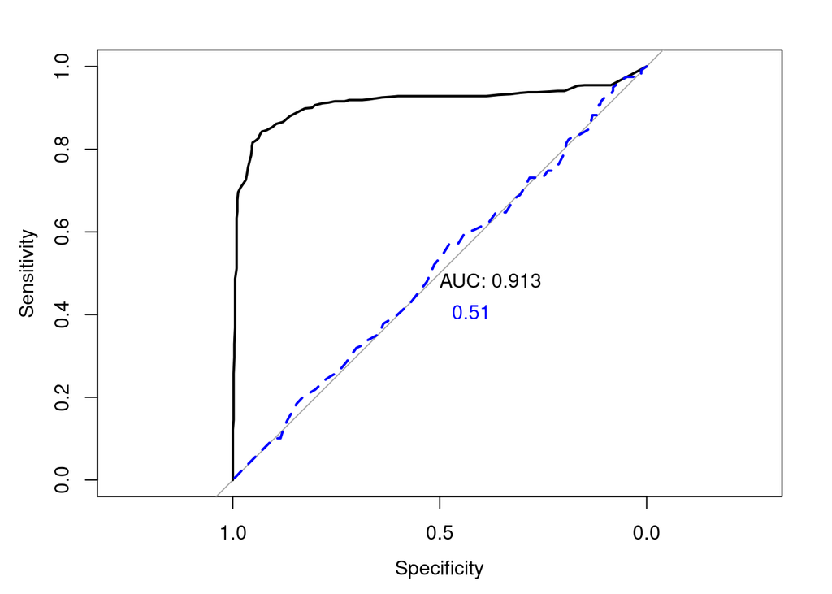

```r
# using base plotting
plot(yt_roc_train, print.auc = T)
lines(yt_roc_test, lty = 2, col = 'blue', print.auc = T)
text(round(auc(yt_roc_test), 3), x = 0.5, y = 0.4, col = "blue", pos = 4)
```

Might be worth reducing the mtry (number of variables to use)

In `randomForest` package, `mtry` controls how many features (predictor variables) are randomly sampled at each split in a decision tree.

If your dataset has a very large number of features, lowering `mtry` can sometimes improve performance by reducing overfitting and promoting greater diversity across individual trees. However, setting it too low may hamper the forest’s ability to find strong predictors.

A feature importance plot helps you see which variables are driving the classification decisions. Importance can be measured via metrics like like the Mean Decrease in Gini (how much splitting on a variable improves node purity).

If you notice that only a few variables dominate the importance chart, or your model takes very long to train, you might try lowering `mtry`.

This can:

- Prevent a handful of strong features from always being chosen.
- Encourage your model to consider a broader range of features at each split, potentially improving generalisation.

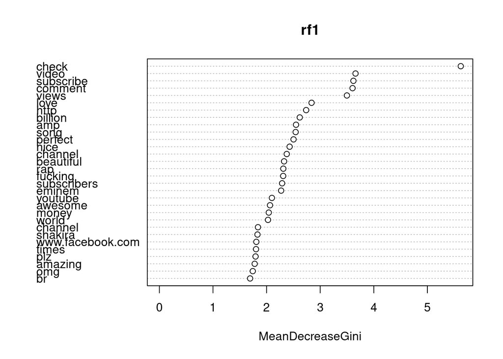

```r
varImpPlot(rf1)
```

# Linguistic Features

Create generalized linguistic features. First I have to load up a linguistic dictionary called NRC Emotion Lexicon. It is available here: https://saifmohammad.com/WebPages/NRC-Emotion-Lexicon.htm And is free for use for research or education, with acknowledgement. Thank you Dr. Saif M. Mohammad at the National Research Council Canada.

I have to read it in as a text file, then convert it to a different format that we can use. You can open up the text file and check out what Dr Mohammad has done to classify words as emotions.

```r
# Split each line into components and convert to a data frame
nrc <- readLines("NRC-Emotion-Lexicon-Wordlevel-v0.92.txt")

data <- do.call(rbind, strsplit(nrc, "\t"))
df <- as.data.frame(data, stringsAsFactors = FALSE)
colnames(df) <- c("Word", "Emotion", "Association")

# Convert Association column to numeric
df$Association <- as.numeric(df$Association)

# Filter out rows where Association is 0, as we're only interested in associations marked as 1
df <- df[df$Association == 1, ]

# Create an empty list to store emotions as keys and associated words as values
emotion_words_dict <- list()

# Populate the list
for (row in 1:nrow(df)) {
  emotion <- df$Emotion[row]
  word <- df$Word[row]

  # Check if the emotion already exists as a key in the list
  if (!is.null(emotion_words_dict[[emotion]])) {
    # Append the word to the existing list of words for this emotion
    emotion_words_dict[[emotion]] <- c(emotion_words_dict[[emotion]], word)
  } else {
    # Create a new entry in the list with this emotion as the key and the word as the value
    emotion_words_dict[[emotion]] <- c(word)
  }
}

emotion_dict <- dictionary(emotion_words_dict)

# Check the structure of the created dictionary
print(emotion_dict)
```

```
## Dictionary object with 10 key entries.
## - [trust]:
##   - abacus, abbot, absolution, abundance, academic, accolade, accompaniment, accord, account, accountability, accountable, accountant, accounts, accredited, accurate, achieve, achievement, acrobat, adhering, administrative [ ... and 1,210 more ]
## - [fear]:
##   - abandon, abandoned, abandonment, abduction, abhor, abhorrent, abominable, abomination, abortion, absence, abuse, abyss, accident, accidental, accursed, accused, accuser, accusing, acrobat, adder [ ... and 1,454 more ]
## - [negative]:
##   - abandon, abandoned, abandonment, abduction, aberrant, aberration, abhor, abhorrent, abject, abnormal, abolish, abolition, abominable, abomination, abort, abortion, abortive, abrasion, abrogate, abscess [ ... and 3,296 more ]
## - [sadness]:
##   - abandon, abandoned, abandonment, abduction, abortion, abortive, abscess, absence, absent, absentee, abuse, abysmal, abyss, accident, accursed, ache, aching, adder, adrift, adultery [ ... and 1,167 more ]
## - [anger]:
##   - abandoned, abandonment, abhor, abhorrent, abolish, abomination, abuse, accursed, accusation, accused, accuser, accusing, actionable, adder, adversary, adverse, adversity, advocacy, affront, aftermath [ ... and 1,225 more ]
## - [surprise]:
##   - abandonment, abduction, abrupt, accident, accidental, accidentally, accolade, advance, affront, aghast, alarm, alarming, alertness, alerts, allure, amaze, amazingly, ambush, angel, anomaly [ ... and 512 more ]
## [ reached max_nkey ... 4 more keys ]
```

I have now used it by applying it to our raw content.

```r
dic_features <- yt %>%
  with(liwcalike(corpus(content, docnames = id),
                 dictionary = emotion_dict,tolower = T)) %>%
  rename(id = docname)
```

We want to find if there are URL’s in the comment. Google provided an answer:

https://stackoverflow.com/questions/3809401/what-is-a-good-regular-expression-to-match-a-url

```r
# website_regex <- "(www\\.)?([a-zA-Z0-9]+(-?[a-zA-Z0-9])*\\.)+[\\w]{2,}(\\/\\S*)?"
website_regex <- "[-a-zA-Z0-9@:%._\\+~#=]{1,}\\.[a-zA-Z0-9()]{1,6}\\b([-a-zA-Z0-9()@:%_\\+.~#?&//=]*)"
yt_url <- yt %>%
  ungroup() %>%
  mutate(content = tolower(content)) %>%
  mutate(url = grepl(website_regex, content)) %>%      #transform to lowercase and use grepl pattern match
  mutate(url = ifelse(url, 1, 0)) %>%
  select(id, url)
```

Now use left_join to join our url findings to our dic_features (joining by id) re-join with original youtube data so can get original info

```r
yt_ling_features <- left_join(dic_features, yt_url) %>%
  left_join(select(yt, id, class, train, content)) %>%
  mutate(class = as.factor(class))
glimpse(yt_ling_features)
```

```
## Rows: 1,710
## Columns: 32
## $ id           <chr> "LZQPQhLyRh80UYxNuaDWhIGQYNQ96IuCg-AYWqNPjpU", "LZQPQhLyR…
## $ Segment      <int> 1, 2, 3, 4, 5, 6, 7, 8, 9, 10, 11, 12, 13, 14, 15, 16, 17…
## $ WPS          <dbl> 13.00, 19.50, 8.00, 12.00, 4.50, 9.50, 4.00, 21.00, 10.00…
## $ WC           <int> 13, 39, 8, 12, 9, 19, 4, 21, 10, 15, 4, 37, 7, 3, 15, 71,…
## $ Sixltr       <dbl> 15.38, 10.26, 12.50, 16.67, 11.11, 10.53, 50.00, 0.00, 10…
## $ Dic          <dbl> 0.00, 10.26, 0.00, 58.33, 22.22, 0.00, 25.00, 0.00, 0.00,…
## $ trust        <dbl> 0.00, 0.00, 0.00, 8.33, 0.00, 0.00, 0.00, 0.00, 0.00, 0.0…
## $ fear         <dbl> 0.00, 0.00, 0.00, 8.33, 11.11, 0.00, 0.00, 0.00, 0.00, 0.…
## $ negative     <dbl> 0.00, 2.56, 0.00, 16.67, 0.00, 0.00, 0.00, 0.00, 0.00, 0.…
## $ sadness      <dbl> 0.00, 2.56, 0.00, 0.00, 0.00, 0.00, 0.00, 0.00, 0.00, 0.0…
## $ anger        <dbl> 0.00, 0.00, 0.00, 0.00, 0.00, 0.00, 0.00, 0.00, 0.00, 0.0…
## $ surprise     <dbl> 0.00, 2.56, 0.00, 0.00, 0.00, 0.00, 0.00, 0.00, 0.00, 0.0…
## $ positive     <dbl> 0.00, 0.00, 0.00, 8.33, 0.00, 0.00, 0.00, 0.00, 0.00, 0.0…
```

[output cut: 19 more lines]

filter into test and train and remove features we don’t want

```r
yt_ling_train <- yt_ling_features %>%
  filter(train == 'train') %>%
  select(-id, -train, -content, -Segment)         #remove variables we don't want
yt_ling_test <- yt_ling_features %>%
  filter(train == 'test') %>%
  select(-id, -train, -content, -Segment)
```

```r
save(yt_ling_features, yt_ling_train, yt_ling_test, file = 'youtube_spam_train_test.rda')
```

# Linguistic Features as Predictors

```r
rf2 <- randomForest(class ~ .,
                    data = yt_ling_train,
                    ntree = 150)
```

It’s still overfit, but its a lot better for the test set. Now, instead of using specific words to predict, we are using generalisable emotions to predict

```r
#train
pred <- tibble(spam_p = predict(rf2, newdata = yt_ling_train, type = 'prob')[,'1'],
               spam = yt_ling_train$class)
yt_roc_train <- roc(data = pred, response = spam, predictor = spam_p)
#test
pred <- tibble(spam_p = predict(rf2, newdata = yt_ling_test, type = 'prob')[,'1'],
               spam = yt_ling_test$class)
yt_roc_test <- roc(data = pred, response = spam, predictor = spam_p)
```

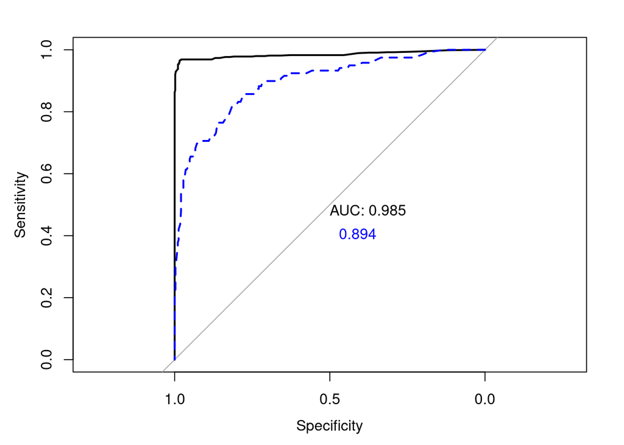

```r
# using base plotting
plot(yt_roc_train, print.auc = T)
lines(yt_roc_test, lty = 2, col = 'blue', print.auc = T)
text(round(auc(yt_roc_test), 3), x = 0.5, y = 0.4, col = "blue", pos = 4)
```

We don’t know the causal direction, so like your assignment, we will create some fake data.

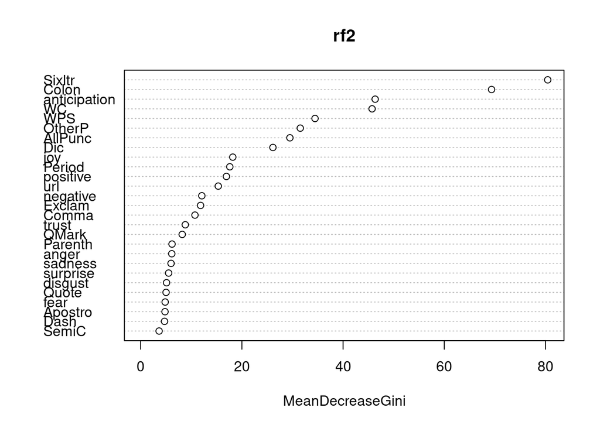

```r
varImpPlot(rf2)
```

# Explaining the RF2 model

First using fake data with 1000 values!

```r
#set.seed(1223)
N <- 1000
g <- seq(min(yt_ling_train$Sixltr),
         max(yt_ling_train$Sixltr),
         length.out = N)
#d <- sample_n(yt_ling_train, 1)
d <- yt_ling_features[38,]

#quick check of a prediction (its a true positive)
predict(rf2, newdata = d)
```

```
## 38
##  1
## Levels: 0 1
```

```r
dn <- d %>%
  mutate(n = N) %>%
  uncount(n) %>%
  mutate(Sixltr = g)
dn$pred <- predict(rf2, newdata = dn, type = "prob")[,2]
```

```r
#Lets play with the most important variable a bit before we look

predict(rf2, newdata =d, type="prob")
```

```
##      0   1
## 38 0.1 0.9
## attr(,"class")
## [1] "matrix" "array"  "votes"
```

```r
d_change <- d %>% mutate(Sixltr = 50)
predict(rf2, newdata =d_change, type="prob")
```

```
##      0   1
## 38 0.1 0.9
## attr(,"class")
## [1] "matrix" "array"  "votes"
```

```r
d_change2 <- d %>% mutate(Sixltr = 2)
predict(rf2, newdata =d_change2, type="prob")
```

```
##            0         1
## 38 0.3733333 0.6266667
## attr(,"class")
## [1] "matrix" "array"  "votes"
```

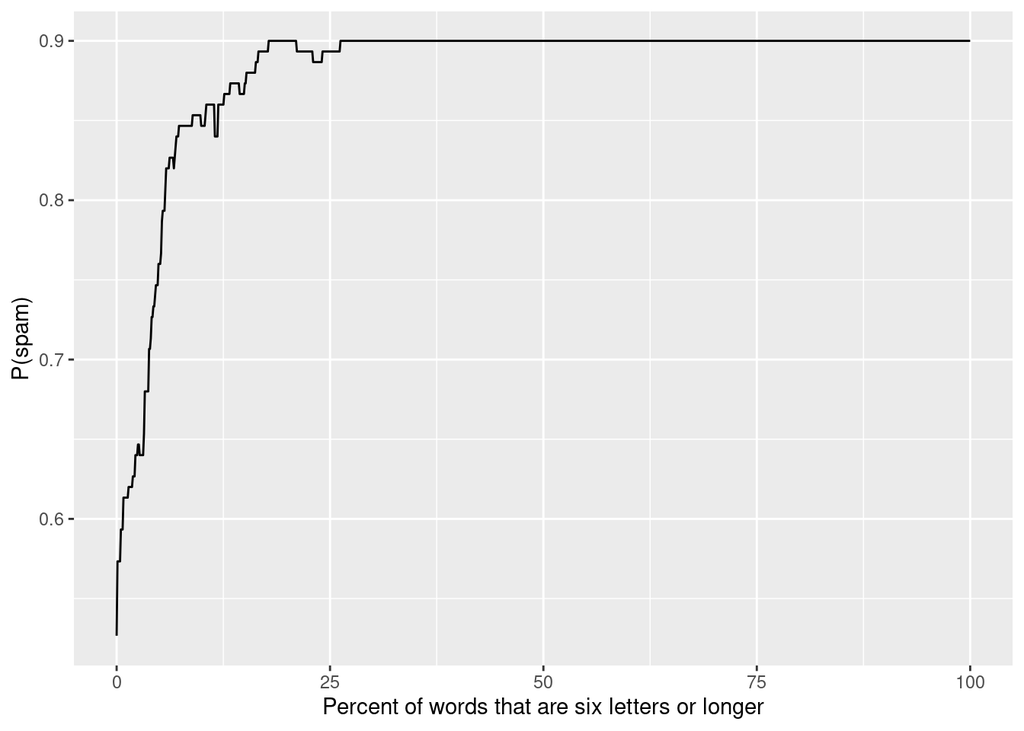

```r
ggplot(dn, aes(x = Sixltr, y = pred)) +
  geom_line() +
  coord_cartesian(xlim = c(0, 100)) +
  xlab("Percent of words that are six letters or longer") +
  ylab("P(spam)")
```

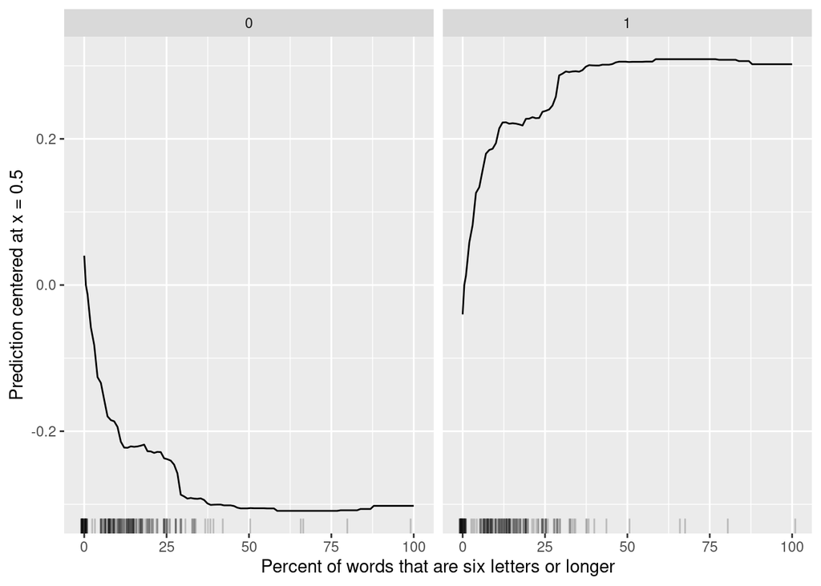

```r
library(iml)
d <- sample_n(yt_ling_train, 200)
yt_pred <- Predictor$new(model = rf2, data = d,
                         y = d$class, type = "prob")
yt_effect <- FeatureEffect$new(yt_pred,center.at = 0.5,
                               grid.size = 100,
                               method = "pdp",
                               feature = "Sixltr")
yt_effect$plot() +
  xlab("Percent of words that are six letters or longer") +
  ylab("P(spam)")
```

—- We can stop here for today! —–

# Topic model

Prep the term document matrix for counts instead of TD-IDF We don’t need to clean, will use all of the words

```r
library(topicmodels)
library(LDAvis)
library(gt)

yt_dtm <- yt_tokens %>%
  count(id, word) %>%
  cast_dtm(id, word, n)
```

Choose the number of topics and run the LDA.

```r
k <- 10
seed <- 2015
yt_lda <- LDA(yt_dtm, k=k, method = 'Gibbs', control=list(seed=seed, burnin=1000, thin=100, iter=1000))
```

Top 10 terms from each topic.

```r
terms(yt_lda, 10) %>%
  as_tibble() %>%
  gt
```

| Topic 1 | Topic 2 | Topic 3 | Topic 4 | Topic 5 | Topic 6 | Topic 7 | Topic 8 | Topic 9 | Topic 10 |
| --- | --- | --- | --- | --- | --- | --- | --- | --- | --- |
| br | guys | https | amp | check | video | views | 39 | subscribe | song |
| quot | free | im | lt | http | youtube | billion | music | channel | love |
| youtube | money | www.facebook.com | nice | mixtape | check | shakira | comment | watch | katy |
| share | visit | watching | gt | awesome | playlist | people | time | videos | perry |
| waka | day | ref | hear | href | channel | pray | world | follow | songs |
| fucking | facebook | cool | 3 | 48051 | it | song | thumbs | shit | girl |
| click | website | 2015 | style | image2you.ru | party | wow | chance | hate | beautiful |
| rapper | paid | guy | gangnam | vote | megan | subscribers | money | plz | omg |
| birthday | twitter | class | http | support | hey | mother | covers | funny | remember |
| miley | online | dance | songs | rand | rock | d | hey | hey | roar |

LDA visualization tool.

```r
lda_json <- createJSON(phi = posterior(yt_lda)$terms,
           theta = posterior(yt_lda)$topics,
           vocab = posterior(yt_lda)$terms %>% colnames,
           doc.length = rowSums(as.matrix(yt_dtm)),
           term.frequency = colSums(as.matrix(yt_dtm)))
serVis(lda_json)
```

Predicting with topics.

You end up with a single dataset (yt_topics) that contains:

All original columns from yt (id, class, etc.) Topic proportion columns (Topic_1, Topic_2, …, Topic_k) for each document. This allows you to use the topics as features for further analysis, such as classification, clustering, or just exploring how topics vary with the class label.

```r
posterior(yt_lda)$topics[1:5, 1:5]
```

```
##                                                      1          2          3
## LZQPQhLyRh80UYxNuaDWhIGQYNQ96IuCg-AYWqNPjpU 0.09090909 0.09090909 0.10909091
## LZQPQhLyRh9-wNRtlZDM90f1k0BrdVdJyN_YsaSwfxc 0.08771930 0.14035088 0.10526316
## LZQPQhLyRh9EXArr4ZnVcDonSbvSMHKYOT24e_qR6fE 0.09615385 0.09615385 0.09615385
## LZQPQhLyRh9MSZYnf8djyk0gEF9BHDPYrrK-qCczIY8 0.11538462 0.09615385 0.09615385
## LZQPQhLyRh9U7Lv_DKpJ7lawpBCotxfgHzBy93Tk028 0.09615385 0.09615385 0.09615385
##                                                      4          5
## LZQPQhLyRh80UYxNuaDWhIGQYNQ96IuCg-AYWqNPjpU 0.10909091 0.09090909
## LZQPQhLyRh9-wNRtlZDM90f1k0BrdVdJyN_YsaSwfxc 0.08771930 0.08771930
## LZQPQhLyRh9EXArr4ZnVcDonSbvSMHKYOT24e_qR6fE 0.09615385 0.11538462
## LZQPQhLyRh9MSZYnf8djyk0gEF9BHDPYrrK-qCczIY8 0.09615385 0.09615385
## LZQPQhLyRh9U7Lv_DKpJ7lawpBCotxfgHzBy93Tk028 0.09615385 0.09615385
```

```r
yt_topics <- posterior(yt_lda)$topics
colnames(yt_topics) <- paste0("Topic_", colnames(yt_topics))

yt_topics <- as_tibble(yt_topics) %>%
  mutate(id = rownames(yt_topics))

yt_topics <- left_join(yt, yt_topics) %>%
  mutate(class = as_factor(class)) %>%
  na.omit()
```

Comments are weighted to every topic - we can use those to make predictions. Create our test/train sets

```r
yt_topic_train <- yt_topics %>%
  filter(train == "train") %>%
  select(class, Topic_1:Topic_10)
yt_topic_test <- yt_topics %>%
  filter(train == "test") %>%
  select(class, Topic_1:Topic_10)
```

```r
rf3 <- randomForest(class ~ ., data = yt_topic_train,
                    ntree = 300)
```

Not as good as the linguistic features, but better than raw words, but you could use both!

```r
#train
pred <- tibble(spam_p = predict(rf3, newdata = yt_topic_train, type = 'prob')[,'1'],
               spam = yt_topic_train$class)
yt_roc_train <- roc(data = pred, response = spam, predictor = spam_p)
#test
pred <- tibble(spam_p = predict(rf3, newdata = yt_topic_test, type = 'prob')[,'1'],
               spam = yt_topic_test$class)
yt_roc_test <- roc(data = pred, response = spam, predictor = spam_p)
```

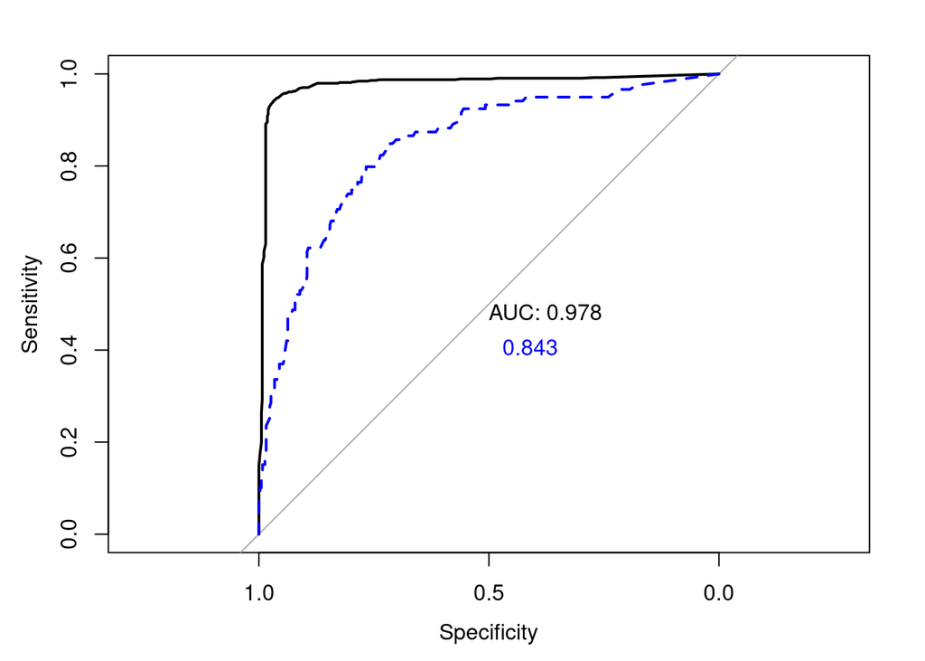

```r
# using base plotting
plot(yt_roc_train, print.auc = T)
lines(yt_roc_test, lty = 2, col = 'blue', print.auc = T)
text(round(auc(yt_roc_test), 3), x = 0.5, y = 0.4, col = "blue", pos = 4)
```

Check most important variables

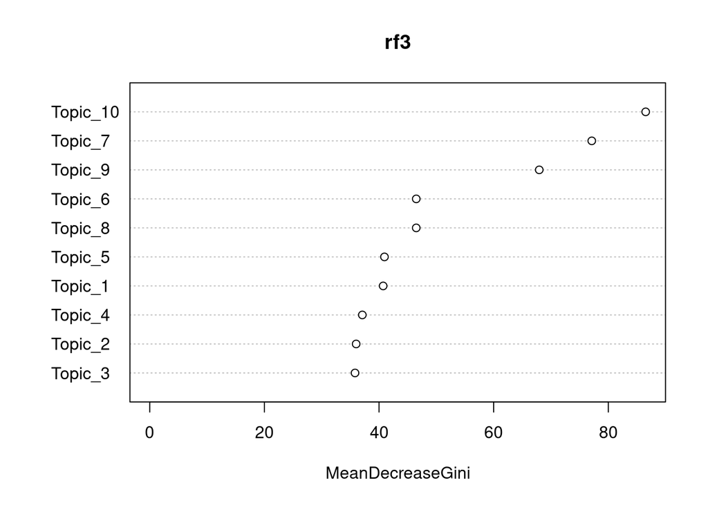

```r
varImpPlot(rf3)
```

What does Topic 10 do?

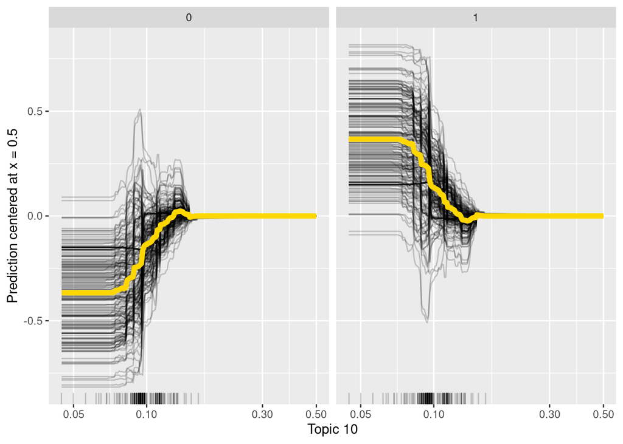

```r
d <- sample_n(yt_topic_train, 200)
yt_pred <- Predictor$new(model = rf3, data=d, y=d$class, type="prob")
yt_effect <- FeatureEffect$new(yt_pred, center.at = 0.5,
                               grid.size = 100,
                               method = "pdp+ice",
                               feature = "Topic_10")

yt_effect$plot() +
  #coord_cartesian(xlim = c(0,100))+
  xlab("Topic 10")+
  ylab("P(spam)")+
  scale_x_log10()
```